# R Crash Course

# Decision and Control statements

These are the bread and butter of computations and algorithms, as they allow computer code to make ‘decisions’ and to repeat calculations or steps over and over again.

## Conditional statements (ifs and elses)

These statements allow you to implement different code (or have your code follow different directions depending on some criteria that can be determined to be `TRUE` or `FALSE`). Statements that test whether something is `TRUE` or `FALSE` are called logical statements and rely on operations like >, <, == or != (for more, see earlier portion of this tutorial)

Say we have some value x having a value between 0 and 1, and we want to round it to be exactly 0 or 1, depending on whether or not it is larger than 0.5.

```r
x<-0.67
```

#### if()

An `if()` statement can help us do this:

```r
if(x >= 0.5){
  x<-1
}
x
```

```
## [1] 1
```

```r
# here, the syntax says:
# if(this stuff is true){
#   carry out all the steps inside of these curly brackets
# }
```

That works pretty well if x is greater than (or equal to) 0.5, but will have no effect on x if it’s less than 0.5 (try it out!)

The best friend of an `if()` is an `else`, which provides instructions on what to do when the if condition is false.

```r
x<-0.2

if(x > 0.5){
    x<-1
}else{
    x<-0
}
x
```

```
## [1] 0
```

```r
# here, the syntax says:
#
# if(this stuff is true){
#   carry out all the steps inside of these curly brackets
# }else{
#   do all of these steps instead
# }
```

#### ifelse()

This is super handy and all, but what if x is a whole bunch of values instead of just one? (ie, x is a vector)? Well, there’s another version of this if/else set up that can operate on vectors or single values:

```r
x<-0.67
ifelse(x >= 0.5, 1, 0)
```

```
## [1] 1
```

```r
# this says:
#   ifelse( if this is TRUE, return this value, otherwise return this value)
```

There’s one important difference in our code: our earlier examples of `if(){}else{}` actually changed the value of x, whereas the `ifelse()` statement above only returned what the new value of x should be. If we check the value of x:

```r
x
```

```
## [1] 0.67
```

it hasn’t changed.

To actually change x we would need to write

```r
x<-ifelse(x >= 0.5, 1, 0)
```

This uses the current value of x, decides if it is less than 0.5 or greater than/equal to 0.5, returns 1 or 0 correspondingly, and saves that value to x, overwriting any previous value saved in x.

Finally, we can apply `ifelse()` to a vector of values:

```r
x<-c(0.97,0.32,0.75,0.49,0.16)
x<-ifelse(x > 0.5, 1, 0)
x
```

```
## [1] 1 0 1 0 0
```

Here the `ifelse()` operation is automatically performed on each element of vector x individually, and the result is itself a vector.

## Loops

When programming, we frequently want to perform the same calculation repeatedly, or on each value of a vector (as in our use of `ifelse()` in the previous example). The structures that allow us to do this are called loops, and come in 2 primary kinds, the `for()` loop and the `while()` loop. The `for()` loop lets us perform a set of calculations a fixed number of times. The `while()` loop performs a set of calculations over and over again until a condition is met (ie, a logical statement goes from being `TRUE` to being `FALSE`).

#### for()

Let’s start with the `for()` loops. Here’s an example:

```r
x<-3
for(i in 1:4){
    print(i)
    x<-x+1
}
```

```
## [1] 1
## [1] 2
## [1] 3
## [1] 4
```

```r
x
```

```
## [1] 7
```

What’s happening here? Let’s take a look at the syntax. First, `for(i in 1:4){ stuff }` says to repeatedly calculate the ‘stuff’ for as many steps as it takes i to go from i=1 to i=4 (by increments of 1 as a default).

What’s the ‘stuff’:

1. `print(i)` tells the `for()` loop to print out the value of i. Every time we run through the loop, the print command is executed. This is why we see:

   ```
   ## [1] 1
   ## [1] 2
   ## [1] 3
   ## [1] 4
   ```

   Each time the loop executes the ‘stuff’, it increases the value of i by 1, starting with i equaling 1 and continuing until i equals 4.
2. `x<-x+1` changes the value of x each time the loop is executed. Basically, it says ‘add 1 to the value of x and overwrite (or update) x to be this new value’. This has the effect of increasing x by 1 every time the loop runs. Using a little math, we would expect then that after running the loop, x should equal its initial value plus 4 (the number of times the loop has run). We can check that out:

   ```r
   x==3+4
   ```

   ```
   ## [1] TRUE
   ```

For a more complicated example, we can use a `for()` loop combined with `if(){}else{}` to accomplish the same task as the `ifelse()` statement above:

As an intermediate step, take a look at how we can use a `for()` loop to focus on each individual element of vector x:

```r
x<-c(0.97,0.32,0.75,0.49,0.16)
for(i in 1:length(x)){
    print(x[i])
}
```

```
## [1] 0.97
## [1] 0.32
## [1] 0.75
## [1] 0.49
## [1] 0.16
```

This `for()` loop starts with i=1 and keeps going until i = `length(x)`, or i = number of elements in vector x. Each time the loop runs, it prints out the value of x[i]. The first time the loop runs, i = 1, so we see x[1], the first element in vector x. The next time the loop runs, i has been increased to i = 2, so we see x[2], the second element of x, and so on until i = `length(x)` and we see the last element of vector x.

Now we can get more sophisticated. This loop is very similar, but instead of printing out the value of each element of x as we go through the loop, here we use an `if(){}else{}` statement to check each individual element of x to see if it is >= 0.5, and then change the value of that element accordingly.

```r
x<-c(0.97,0.32,0.75,0.49,0.16)
for(i in 1:length(x)){
    if(x[i]>=0.5){
        x[i]<-1
    }else{
        x[i]<-0
    }
}
x
```

```
## [1] 1 0 1 0 0
```

Can you use a `for()` loop and an `if(){}else{}` statement to determine if a list of values is even or odd? How about with the `ifelse()` function?

#### while()

Sometimes we won’t know ahead of time how many times we want to repeat a set of calculations. `while()` loops can be useful in these situations, because they let us repeat calculations indefinitely, until a logical statement goes from being `TRUE` to being `FALSE`.

For example, say that we want to keep drawing random numbers between 0 and 1, until we get a number greater than 0.8:

```r
current.number<-0   # set this number to be less than 0.8 so that our loop will run at least the first time.
while(current.number<=0.8){
    current.number<-runif(1)    # runif(1) generates 1 random number from a uniform distribution ranging from 0 to 1 - don't sweat the details yet.
    print(current.number)
}
```

```
## [1] 0.009868371
## [1] 0.1177029
## [1] 0.7158915
## [1] 0.5027787
## [1] 0.8893759
```

```r
# syntax:
#   while(this statement is true){
#       run this stuff
#   }
```

Try running that code several times, and observe its behavior. Each time it runs, it should spit out a list of a varying number of decimal numbers, where only the last number is greater than 0.8. (It’s different each time because we are generating different random numbers each time the loop executes).

CAUTION: `while()` loops can be super useful, but they are also dangerous, because they can lead to something called an ‘infinite loop’. Basically, if the logical statement can never become false, then the loop will just keep on running forever and ever, until your computer or battery dies or gets shut off, or you close the program. This is a pretty undesireable thing to have happen.

BEFORE you try the example below, make sure you know how to stop a piece of code that’s running in your R console. Unfortunately, this depends on what operating system you’re using as well how you’re working with R (RStudio, default R, or some other interface). In RStudio you can click on the consol then hit ‘Esc’ (escape) and that should end the currently running calculation. On the basic R program, there’s a red stop sign in the upper left hand corner of the R console, which works - sometimes. You can also try typing ctrl + c (or command + c on a mac?). When you get tired of the infinite loop running, you need to use one of these approaches to stop it - it won’t stop on its own.

Note that these approaches won’t always stop R from executing the code you’ve asked it to evaluate, depending on some technical details. For this reason, it’s always a good idea to save your code, etc. before running a function that might get caught in an infinite loop, or otherwise take a really long time. Sometimes the only way to stop R is to close and restart it.

Here’s an example of an infinite loop - be bold!

```r
while(2>1){
    print("to infinity and beyond!")
}
```

One way to prevent an infinite loop is to set an upper limit on the number of times that the while loop can be executed:

```r
counter<-1
current.number<-0
while(current.number<=0.99 & counter<=50){
    current.number<-runif(1)
    print(c(counter,current.number))
    counter<-counter+1
}
```

```
## [1] 1.0000000 0.5602566
## [1] 2.00000000 0.01716226
## [1] 3.0000000 0.6238977
## [1] 4.0000000 0.9936638
```

Run this a couple of times and see how it behaves. Sometimes the output will stop because the loop encounters a number greater than 0.99 before it tries 50 times. But sometimes the counter gets to 50 and our while loop is halted before we observe a number greater than 0.99.

This can be super handy if we made a type-o when writing our loop, and wrote 99 instead of 0.99. Without the counter, this loop would never stop, because our random numbers will always be less than 99. With the counter, it will automatically stop after 50 attempts.

```r
counter<-1
current.number<-0
while(current.number<=99 & counter<=50){
    current.number<-runif(1)
    print(c(counter,current.number))
    counter<-counter+1
}
```

```
## [1] 1.0000000 0.6258043
## [1] 2.000000 0.364695
## [1] 3.0000000 0.8050016
## [1] 4.00000000 0.06405364
## [1] 5.0000000 0.3936473
## [1] 6.0000000 0.4098955
## [1] 7.0000000 0.8104721
## [1] 8.0000000 0.6715562
## [1] 9.0000000 0.4705053
## [1] 10.0000000  0.7781597
## [1] 11.0000000  0.8179546
## [1] 12.0000000  0.4441512
## [1] 13.0000000  0.4282374
## [1] 14.00000000  0.06368088
## [1] 15.0000000  0.7980993
```

[output cut: 35 more lines]

## Advanced loops

R has a set of functions that serve as alternatives to the classic `for()` loop as it’s used to perform calculations on the elements of a vector, with advantages in terms of how quickly they run, and how concisely they can be written. This tutorial will mention them only briefly, but they’re well worth learning more about:

#### apply(), sapply(), lapply(), tapply()

```r
?apply()
?sapply()
?lapply()
?tapply()
```

Let’s return to our example of classifying numbers between 0 and 1 as either 0 or 1 exactly:

```r
x<-c(0.97,0.32,0.75,0.49,0.16)
sapply(x, FUN=function(y) if(y>=0.5){y<-1}else{y<-0})
```

```
## [1] 1 0 1 0 0
```

This is equivalent to what we did before,

```r
ifelse(x>=0.5,1,0)
```

```
## [1] 1 0 1 0 0
```

but far more flexible, because we could put any function that we want to after the FUN= part in the call to `sapply()`. This is a handy way of applying any general function of interest to all of the elements of a vector.

These advanced loop functions come in several flavors. `apply()` works on the columns or rows of a matrix; `lapply()` works on the elements of a ‘list’ - a kind of data structure in R that we haven’t covered yet, but will run into shortly.

# Data manipulation (Advanced):

## Importing data

NOTE: For this exercise you’ll need the two data files found at http://www.msu.edu/~kremerco/frog_pred.csv http://www.msu.edu/~kremerco/frog_pred.txt

So far, all of the ‘data’ that we’ve worked with in R we’ve either entered by hand, or generated using functions like `seq()`, `rep()`, and `sample()`. For R to be useful in analyzing real data sets, we need to learn how to load (or read) existing data sets from other files, as it would be a nightmare to have to enter data by hand into R. Fortunately, this is quite easy to do, for a variety of file formats.

My personal preference is to work with .csv, or comma separated value files (which can be created in excel). So that’s what I’ll demonstrate first:

#### read.csv()

This function `read.csv("filepath")` reads a .csv file located at “filepath” into R as a data frame. If you’re trying this out on your own computer (as you should), you’ll need to change the file path below to reflect the location of the frog_pred.csv file that you just downloaded on your own computer.

```r
data<-read.csv("/Users/colin/Teaching/ELME/ELME 2015/frog_pred.csv")
head(data)
```

```
##   density pred  size surv propsurv
## 1      10   no   big    9      0.9
## 2      10   no   big   10      1.0
## 3      10   no   big    7      0.7
## 4      10   no   big   10      1.0
## 5      10   no small    9      0.9
## 6      10   no small    9      0.9
```

Alternatively, you can instruct R to let you browse through your file directories to select a particular file to load.

```r
data<-read.csv(file=file.choose())    # this can be convenient, but also problematic, because it doesn't leave behind a permanent record of what data file you actually loaded, potentially making it hard to remember what you did later.
```

#### read.table()

If your data are saved in a format that’s not a .csv file, you may still be able to load it in to R, from a .txt text file format (among others) using the `read.table()` command:

```r
data<-read.table("/Users/colin/Teaching/ELME/ELME 2015/frog_pred.txt",sep=",",header=T)
```

Here I’ve specified that the character used to separate different elements in the data is a comma, via `sep=","`. I’ve also told `read.table()` that the file has a header (with column names), via `header=T` . Many many more options are available, so be sure to check out the help file at `?read.table()`

## Working directory

Every time you open up R, it defaults to calling a particular directory directory on your computer its ‘home’ or its ‘working directory’. This becomes the first place that it looks when you tell it to load data, and also the location where any files you tell R to create are saved.

#### getwd(), setwd()

To find out what R thinks your working directory is right now, try:

```r
getwd()
```

```
## [1] "/Users/colin/Research/Software/CrashCourse"
```

Often, the default or initial directory isn’t the one that you want to be working in for a particular project. It’s important then to be able to change the current working directory. You can do this typically through the file menus in R, but also directly by setting the working directory via the command `setwd()`:

```r
setwd("/Users/colin/Teaching/ELME/ELME 2015/")
```

Again, the advantage to doing this is that any files we create will be saved to this folder (unless we explicitly specify a different location when saving files).

Additionally, when it comes to loading data files, we can take a short cut and just write

```r
read.csv("frog_pred.csv")
```

which avoids the need to write out the complete file path, because R defaults to looking in the current working directory.

## Practice looking at data

This particular data set we’ve just loaded describes the results of an experiment looking at predation on frogs as a function of frog size, and the density of frogs in a tank.

Several functions that we learned earlier are quite useful for quickly looking at these data:

```r
dim(data)
```

```
## [1] 48  5
```

```r
names(data)
```

```
## [1] "density"  "pred"     "size"     "surv"     "propsurv"
```

```r
head(data)
```

```
##   density pred  size surv propsurv
## 1      10   no   big    9      0.9
## 2      10   no   big   10      1.0
## 3      10   no   big    7      0.7
## 4      10   no   big   10      1.0
## 5      10   no small    9      0.9
## 6      10   no small    9      0.9
```

```r
str(data)
```

```
## 'data.frame':    48 obs. of  5 variables:
##  $ density : int  10 10 10 10 10 10 10 10 10 10 ...
##  $ pred    : Factor w/ 2 levels "no","pred": 1 1 1 1 1 1 1 1 2 2 ...
##  $ size    : Factor w/ 2 levels "big","small": 1 1 1 1 2 2 2 2 1 1 ...
##  $ surv    : int  9 10 7 10 9 9 10 9 4 9 ...
##  $ propsurv: num  0.9 1 0.7 1 0.9 0.9 1 0.9 0.4 0.9 ...
```

In particular, str(data) shows us that this data consists of 5 columns, containing integers (density and surv columns), numbers (propsurv column), and lastly, these curious things called Factors, which we haven’t run into before in this tutorial.

## Factors

Factors are both a terrifically useful and a terrible type (or class) of variable. They exist simultaneously as both character data and numerical data, which can make them quite confusing to work with. It’s worth spending a little bit of time learning about them here, because they *will* cause you trouble sooner or later.

To try to understand what it means for factors to be both characters and numeric, let’s focus on the predation column first:

```r
data$pred           # here's what the whole vector looks like if we ask for it directly
```

```
##  [1] no   no   no   no   no   no   no   no   pred pred pred pred pred pred
## [15] pred pred no   no   no   no   no   no   no   no   pred pred pred pred
## [29] pred pred pred pred no   no   no   no   no   no   no   no   pred pred
## [43] pred pred pred pred pred pred
## Levels: no pred
```

```r
class(data$pred)    # the class of this vector is "factor"
```

```
## [1] "factor"
```

To get a more informative view of what this factor `data$pred` consists of, it helps to apply a function called `unclass()`, which just removes the ‘factor’ class from this vector.

```r
unclass(data$pred)
```

```
##  [1] 1 1 1 1 1 1 1 1 2 2 2 2 2 2 2 2 1 1 1 1 1 1 1 1 2 2 2 2 2 2 2 2 1 1 1
## [36] 1 1 1 1 1 2 2 2 2 2 2 2 2
## attr(,"levels")
## [1] "no"   "pred"
```

Here we can see that the vector itself consists of 1’s and 2’s, but that the vector has an extra attribute attached to it called ‘levels’, which contain the labels (character strings) “no” and “pred”.

This factor implicitly matches * “no” to 1, and * “pred” to 2

On the surface this seems like a crazy scheme - why on earth would we want both numerical and character data mashed together in the same column and called a factor?

It turns out that for many statistical models it is much more convenient to work with a vector of integers describing which treatment or category a particular data point is a member of, rather than characters or names. Basically, it’s easier for computers to work with numbers, which are easier for performing computations. However, long lists of integers aren’t meaningful to (most?) humans - we remember what different treatments mean much more easily if they are referred to by a name than by a number. Factors attempt to retain categorical data in a form that is convenient for use in statistical modeling but also easy for humans to look at and understand as well - a worthy goal.

Factors can cause problems though if not handled carefully - we have to make sure that they give us characters when we want characters, and numbers when we want to work with the corresponding numerical codes. For this reason, you will often see factors converted into other data classes, like character or numerical.

#### as.character(), as.numeric()

For example:

```r
data$pred.character<-as.character(data$pred)
data$pred.numeric<-as.numeric(data$pred)
# here we've added two new columns to our data frame, pred.character and pred.numeric, by forcing a factor, data$pred, into a character or numerical form.
```

What’s the result of this:

```r
str(data)
```

```
## 'data.frame':    48 obs. of  7 variables:
##  $ density       : int  10 10 10 10 10 10 10 10 10 10 ...
##  $ pred          : Factor w/ 2 levels "no","pred": 1 1 1 1 1 1 1 1 2 2 ...
##  $ size          : Factor w/ 2 levels "big","small": 1 1 1 1 2 2 2 2 1 1 ...
##  $ surv          : int  9 10 7 10 9 9 10 9 4 9 ...
##  $ propsurv      : num  0.9 1 0.7 1 0.9 0.9 1 0.9 0.4 0.9 ...
##  $ pred.character: chr  "no" "no" "no" "no" ...
##  $ pred.numeric  : num  1 1 1 1 1 1 1 1 2 2 ...
```

Notice the addition of columns `$pred.character` and `$pred.numeric` to the data frame, and the class of variable that they have become (character and numeric, respectively)

Alternatively, we can take a character vector and convert it into a factor by doing something like this: `as.factor(data$pred.character)`.

#### levels()

The function `levels()` can be a useful way of finding out what levels of a factor exist:

```r
levels(data$pred)
```

```
## [1] "no"   "pred"
```

## Locating particular values in a vector

Sometimes we have a vector of data and we know that it contains particular pieces of data, but we don’t know where in the vector they occur. There’s a function that was made for this situation (literally)

#### which()

The function `which()` tells us the integers corresponding to the positions in a vector satisfying some logical condition. In otherwords, it tells us where in a vector particular values occur. For example,

```r
which(data$density>10)  # which elements in data$density are larger than 10?
```

```
##  [1] 17 18 19 20 21 22 23 24 25 26 27 28 29 30 31 32 33 34 35 36 37 38 39
## [24] 40 41 42 43 44 45 46 47 48
```

If we save them we can use these integer locations to do some useful things. For example we can look at the proportion of frogs surviving predation (data$propsurv) when the density of frogs is > 10:

```r
locations<-which(data$density>10)
data$propsurv[locations]
```

```
##  [1] 0.9600000 0.9200000 0.8800000 1.0000000 0.9200000 0.9200000 0.9200000
##  [8] 0.8400000 0.2400000 0.5200000 0.1600000 0.3600000 0.5200000 0.8000000
## [15] 0.3200000 0.4000000 0.9714286 0.9428571 0.9428571 0.8857143 0.8857143
## [22] 1.0000000 0.9428571 0.9142857 0.1142857 0.3428571 0.3714286 0.4000000
## [29] 0.6285714 0.3428571 0.8857143 0.4857143
```

```r
data$density[locations]
```

```
##  [1] 25 25 25 25 25 25 25 25 25 25 25 25 25 25 25 25 35 35 35 35 35 35 35
## [24] 35 35 35 35 35 35 35 35 35
```

This is similar to an approach introduced earlier:

```r
data$propsurv[data$density>10]
```

```
##  [1] 0.9600000 0.9200000 0.8800000 1.0000000 0.9200000 0.9200000 0.9200000
##  [8] 0.8400000 0.2400000 0.5200000 0.1600000 0.3600000 0.5200000 0.8000000
## [15] 0.3200000 0.4000000 0.9714286 0.9428571 0.9428571 0.8857143 0.8857143
## [22] 1.0000000 0.9428571 0.9142857 0.1142857 0.3428571 0.3714286 0.4000000
## [29] 0.6285714 0.3428571 0.8857143 0.4857143
```

which works because `data$density>10` produces a logical vector (a vector consisting of `TRUE` and `FALSE`),

```r
data$density>10
```

```
##  [1] FALSE FALSE FALSE FALSE FALSE FALSE FALSE FALSE FALSE FALSE FALSE
## [12] FALSE FALSE FALSE FALSE FALSE  TRUE  TRUE  TRUE  TRUE  TRUE  TRUE
## [23]  TRUE  TRUE  TRUE  TRUE  TRUE  TRUE  TRUE  TRUE  TRUE  TRUE  TRUE
## [34]  TRUE  TRUE  TRUE  TRUE  TRUE  TRUE  TRUE  TRUE  TRUE  TRUE  TRUE
## [45]  TRUE  TRUE  TRUE  TRUE
```

and only the elements of data$propsurv where `TRUE` occurs are retained.

#### %in%

It’s also possible to use a short cut called `%in%` to figure out the intersection of lists of values, which can be really handy at times.

Here’s an example. Supposed we have a list of letters:

```r
letters<-c("a","d","e","a","f","b","b")
```

If we want to pull out every instance of the letter “a” we could do something like this:

```r
letters[letters=="a"]
```

```
## [1] "a" "a"
```

But maybe we’re interested in more than one letter, perhaps “a” and “b” and we want to find all instances of either letter. We’ve got a few options:

1. This works, but it’s long, and gets longer with each additional case we’re looking for.

   ```r
   letters[letters=="a" | letters=="b"]
   ```

   ```
   ## [1] "a" "a" "b" "b"
   ```

2. This is much shorter/more efficient:

   ```r
   letters[letters %in% c("a","b")]
   ```

   ```
   ## [1] "a" "a" "b" "b"
   ```

Let’s tear apart this second example. The code:

```r
letters %in% c("a","b")
```

```
## [1]  TRUE FALSE FALSE  TRUE FALSE  TRUE  TRUE
```

checks each element of letters one at a time, to see if it appears in the list of interesting cases after `%in%`, returning `TRUE` or `FALSE`. The `TRUE`/`FALSE` list is then used to spit back only the entries of ‘letters’ that we’re interested in.

## Accessing a subset of your data

It is often desirable to be able to focus on a subset of your entire data set, rather than trying to analyze or work with the whole beast at once. The methods introduced above can be used to accomplish this. Here are some examples:

1. Create a subset of data with only the rows in which `data$density` is equal to 10 (but including all columns):

   ```r
   data2<-data[data$density==10,]
   data2
   ```

   ```
   ##    density pred  size surv propsurv pred.character pred.numeric
   ## 1       10   no   big    9      0.9             no            1
   ## 2       10   no   big   10      1.0             no            1
   ## 3       10   no   big    7      0.7             no            1
   ## 4       10   no   big   10      1.0             no            1
   ## 5       10   no small    9      0.9             no            1
   ## 6       10   no small    9      0.9             no            1
   ## 7       10   no small   10      1.0             no            1
   ## 8       10   no small    9      0.9             no            1
   ## 9       10 pred   big    4      0.4           pred            2
   ## 10      10 pred   big    9      0.9           pred            2
   ## 11      10 pred   big    7      0.7           pred            2
   ## 12      10 pred   big    6      0.6           pred            2
   ## 13      10 pred small    7      0.7           pred            2
   ## 14      10 pred small    5      0.5           pred            2
   ## 15      10 pred small    9      0.9           pred            2
   ## 16      10 pred small    9      0.9           pred            2
   ```

2. Or a subset with only the rows where density equals 10 and size equals ‘big’

   ```r
   data3<-data[data$density==10 & data$size=="big",]
   data3
   ```

   ```
   ##    density pred size surv propsurv pred.character pred.numeric
   ## 1       10   no  big    9      0.9             no            1
   ## 2       10   no  big   10      1.0             no            1
   ## 3       10   no  big    7      0.7             no            1
   ## 4       10   no  big   10      1.0             no            1
   ## 9       10 pred  big    4      0.4           pred            2
   ## 10      10 pred  big    9      0.9           pred            2
   ## 11      10 pred  big    7      0.7           pred            2
   ## 12      10 pred  big    6      0.6           pred            2
   ```

3. The `which()` command can be used for these purposes as well:

   ```r
   locations<-which(data$density==10 & data$size=="big")
   data4<-data[locations,]
   data4
   ```

   ```
   ##    density pred size surv propsurv pred.character pred.numeric
   ## 1       10   no  big    9      0.9             no            1
   ## 2       10   no  big   10      1.0             no            1
   ## 3       10   no  big    7      0.7             no            1
   ## 4       10   no  big   10      1.0             no            1
   ## 9       10 pred  big    4      0.4           pred            2
   ## 10      10 pred  big    9      0.9           pred            2
   ## 11      10 pred  big    7      0.7           pred            2
   ## 12      10 pred  big    6      0.6           pred            2
   ```

#### subset()

Finally, there’s an explicit command called `subset()` that can be used as well:

```r
data5<-subset(data,data$density==10 & data$size=='big')
data5
```

```
##    density pred size surv propsurv pred.character pred.numeric
## 1       10   no  big    9      0.9             no            1
## 2       10   no  big   10      1.0             no            1
## 3       10   no  big    7      0.7             no            1
## 4       10   no  big   10      1.0             no            1
## 9       10 pred  big    4      0.4           pred            2
## 10      10 pred  big    9      0.9           pred            2
## 11      10 pred  big    7      0.7           pred            2
## 12      10 pred  big    6      0.6           pred            2
```

# Data review/Descriptive statistics:

It can be helpful to be able to generate quick numerical summaries of different portions of your data. Here are some relevant functions:

#### summary()

The function `summary()` provides basic summary statistics for different classes of data.

```r
summary(data)             # for entire data frames
```

```
##     density        pred       size         surv          propsurv
##  Min.   :10.00   no  :24   big  :24   Min.   : 4.00   Min.   :0.1143
##  1st Qu.:10.00   pred:24   small:24   1st Qu.: 9.00   1st Qu.:0.4964
##  Median :25.00                        Median :12.50   Median :0.8857
##  Mean   :23.33                        Mean   :16.31   Mean   :0.7216
##  3rd Qu.:35.00                        3rd Qu.:23.00   3rd Qu.:0.9200
##  Max.   :35.00                        Max.   :35.00   Max.   :1.0000
##  pred.character      pred.numeric
##  Length:48          Min.   :1.0
##  Class :character   1st Qu.:1.0
##  Mode  :character   Median :1.5
##                     Mean   :1.5
##                     3rd Qu.:2.0
##                     Max.   :2.0
```

```r
summary(data$propsurv)  # or single vectors
```

```
##    Min. 1st Qu.  Median    Mean 3rd Qu.    Max.
##  0.1143  0.4964  0.8857  0.7216  0.9200  1.0000
```

#### table()

The function `table()` reports the number of times each unique value can be found in a given vector.

```r
table(data$density)
```

```
##
## 10 25 35
## 16 16 16
```

Or for multiple vectors:

```r
table(data$density,data$pred)
```

```
##
##      no pred
##   10  8    8
##   25  8    8
##   35  8    8
```

#### mean(), var(), sd(), median(), quantile()

There are several other self explanatory functions:

```r
mean(data$propsurv)                             # mean of data
```

```
## [1] 0.7216071
```

```r
median(data$propsurv)                           # median of data
```

```
## [1] 0.8857143
```

```r
quantile(data$propsurv,probs=c(0.05,0.5,0.95))  # any given quantile
```

```
##        5%       50%       95%
## 0.2680000 0.8857143 1.0000000
```

```r
var(data$propsurv)                              # variance
```

```
## [1] 0.0709773
```

```r
sd(data$propsurv)                                 # standard deviation
```

```
## [1] 0.2664157
```

# Plotting data

An essential part of understanding your data is visualizing it. There are entire books on this topic, and a R is a powerful tool for customized plotting. For now, here are some basic commands to get us started:

#### plot()

To make a scatter plot of bivariate data, try `plot()`

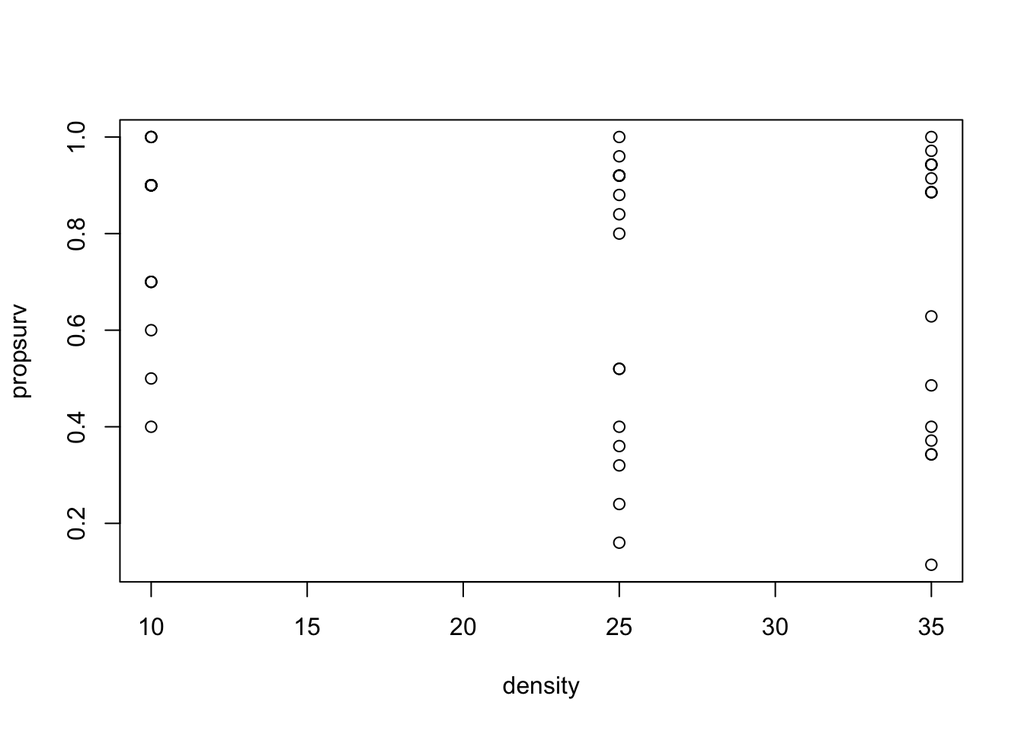

```r
# Syntax: plot(y values ~ x values, data=name.of.data.frame.containing.x.and.y)
plot(propsurv~density,data=data)
```

#### boxplot()

To make a box plot, try `boxplot()`

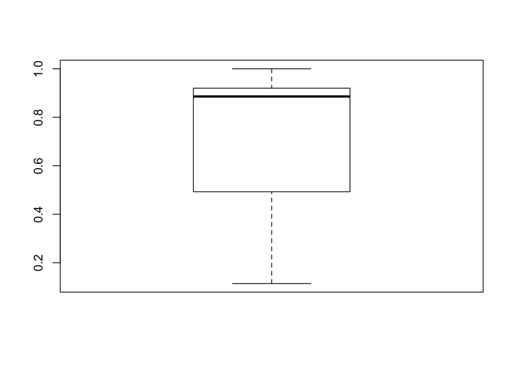

```r
boxplot(data$propsurv)
```

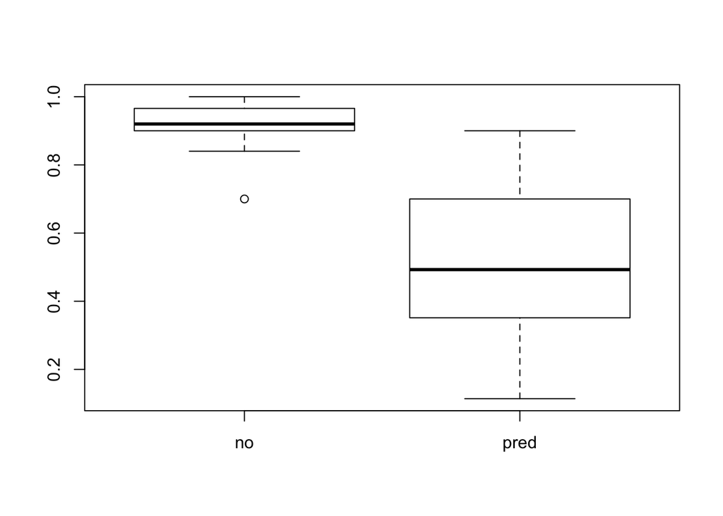

```r
boxplot(data$propsurv~data$pred)
```

#### abline(), segments(), points()

We can add lines, segments and points to a figure:

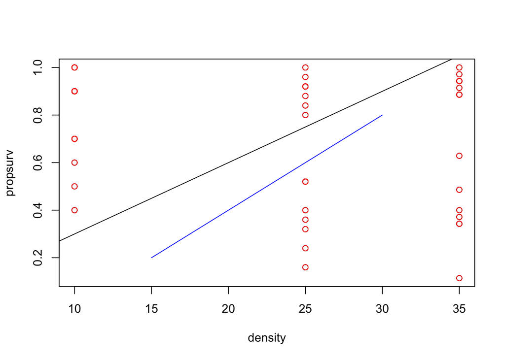

```r
plot(propsurv~density,data=data)
abline(0,0.03)          # add a line with given intercept, slope
segments(15,0.2,30,0.8,col='blue')            # add a (blue) line segment given its endpoints
points(data$propsurv~data$density,col='red')  # add (red) points to a plot
```

Much more on plotting can be found in upcoming lab activities, where we have more data to play with and visualize.

# R packages

As mentioned earlier, there are an enormous number of functions and tools that the R community has developed. Many of them are highly specialized, so the basic distribution of R comes with only a subset of all possible functions installed. To access the other functions that people have written, there are 2 approaches:

1. If the functions/tools are bundled together and available in a formal R package (like the maximum likelihood tools we’ll be using, which are located in a package called ‘bbmle’), you can download and install the desired package via the `install.packages()` command:

```r
install.packages("bbmle")
```

You can also do this using menus/windows of your R gui. For example, in RStudio, there’s a ‘Packages’ tab at the top of the panel in the lower right of the screen, where you can see what packages you have loaded or installed, as well as search for new packages.

When you want to actually use a package that you have downloaded and installed, you have to load it - usually every time you restart R. This can be accomplished with the `library()` command, as in:

```r
library(bbmle)
```

2. Often people will have written a couple of useful little functions that they haven’t turned into a formal R package (which takes more work). This is something that you might even do yourself. If these extra functions are kept in an R script (a file ending in .R), you can instruct R to go open that script and silently execute everything it contains - basically like loading your own personal functions. The command for this is `source()`:

```r
source("name_of_script.R")
```

All for now. Contact me with any questions or corrections at colin [.] kremer [at] yale [.] edu

Hope this was helpful!